# PEMFC + FEML

Missing Physics Discovery를 FEniCSx + PyTorch로 구현하기 · 검증 사다리 A1–A4

신건호

# 구현 로드맵

## FEM–ML 연결고리 — 왜 Adjoint인가

파라미터 $\theta$가 $P$개, 손실 $J$는 스칼라 하나. 그래디언트를 어떻게 구할까?

$$\frac{dJ}{d\theta} = \frac{\partial J}{\partial u}\,\frac{\partial u}{\partial \theta},
\qquad
K_T\,\frac{\partial u}{\partial \theta} = -\frac{\partial F}{\partial \theta}$$

- **forward mode**: $\partial u/\partial\theta$를 직접 구함 → 선형계를 **$P$번** 풀이
- **adjoint mode**: 결합 순서를 재배치 → 선형계를 **1번**만 풀이

파라미터가 몇 개든 상관없이 그래디언트 전체를 한 번의 선형계 풀이로 얻는 것 — 이게 이 프로젝트 전체가 성립하는 이유다.

## 전치가 나오는 이유

$\dfrac{dJ}{d\theta} = -\dfrac{\partial J}{\partial u}K_T^{-1}\dfrac{\partial F}{\partial\theta}$ 에서 $\dfrac{\partial J}{\partial u}K_T^{-1}$ 를 묶으면:

$$\frac{dJ}{d\theta} = -\psi^\top\frac{\partial F}{\partial\theta},
\qquad
\boxed{\ K_T^{\top}\psi = \frac{\partial J}{\partial u}\ }$$

- $\psi$ = 영향 함수 (influence function) / 라그랑주 승수
- 연산자를 내적의 반대편 인자로 넘기는 것 = **adjoint**(수반)
- 그래서 `ksp.solveTranspose`가 등장한다

## 두 구간의 이음매

```
θ ──[FEM 순전파]──▶ u ──▶ J
J ──[FEM adjoint, solveTranspose]──▶ ∂J/∂D_eff ──[torch .backward()]──▶ θ
```

$$\frac{\partial J}{\partial D_{\text{eff}}}\bigg|_{qp} = \pm\, w_{qp}\,(\nabla C\cdot\nabla\psi)_{qp}$$

- FEM 쪽 `solveTranspose`(손코딩)와 PyTorch `backward()`(자동)는 **같은 원리**
- VJP(위 식)가 두 구간을 잇는 지점 — `.backward(dJdG)`에 넘기는 인자

## 전체 로드맵

FEML_FEniCSx_Implementation 6.2–6.19 재사용, 검증 사다리를 A1→A2→A3→A4로 확장:

$$\underbrace{\text{A1}}_{\text{선형}}
\;\to\;
\underbrace{\text{A2}}_{+\,\text{경계항}}
\;\to\;
\underbrace{\text{A3}}_{+\,\text{비선형}}
\;\to\;
\underbrace{\text{A4}}_{+\,\text{box 제약}}
\;\to\;
\underbrace{\text{B}}_{+\,\text{mixed space}}
\;\to\;
\text{본체}$$

**원칙**: 매 단계마다 축을 **하나만** 추가 — 실패 원인을 항상 하나로 좁힌다.

본체로 미루는 것: continuation, 3필드 실제 결합, 실제 $s$(=$C_w$의 함수)

# A1. 확산항 (선형 배선)

## 점검 목표

adjoint 배선의 골격이 맞는가 — 가장 싼 문제에서 확인.

- 산소 방정식 **단독**, $s$는 **고정 배경 필드**, 순전파 **선형**
- $D_{\text{eff}}$만 학습 대상, $K_{\text{corr}}$ 없음

$$\nabla\cdot(D_{\text{eff}}\nabla C) - \nabla\cdot(C\mathbf W) + \nabla\cdot(C\,\mathbf j_l) = 0,
\qquad
D_{\text{eff}} = \rho_g\,\mathcal G_\theta(s)\,D$$

## 스니펫 — adjoint 부호 (선형 규약)

$$K_T^{\top}\psi = -\frac{2r}{\lVert o\rVert^2},
\qquad
\frac{\partial J}{\partial D_{\text{eff}}} = +\,w_{qp}(\nabla C\cdot\nabla\psi)$$

```python
rr = -2.0*r/denom                          # rhs
ksp.solveTranspose(rr, psi)
dJdDeff = qw*(gC*gP).sum(axis=1)           # VJP: +  (두 마이너스가 상쇄)
```

## 결과

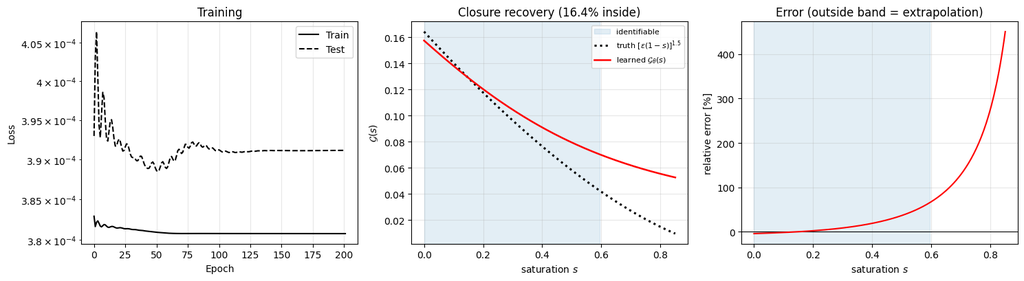

| 항목 | 값 |
| --- | --- |
| 그래디언트 검증 (최소 \|ratio−1\|) | **1.91 × 10⁻⁵** @ h=1e-4 |
| 복원 오차 (식별 구간 내부, $s\in[0,0.595]$) | 16.4% |
| 복원 오차 (구간 외부, 외삽) | 182.2% (예상된 정상 범위) |
| 학습 | 201 epoch, best epoch 51 |

## 남기는 문제

큰 $s$ ($>0.5$)가 도메인 적분점의 **1.2%**뿐 → 학습 신호 부족.

→ **데이터 설계의 한계지 배선 문제 아님.**

# A2. Tafel식 (경계항)

## 점검 목표

경계적분이 좌변 행렬에 처음 들어갈 때도 `solveTranspose` adjoint가 그 항을 반영하는가.

**중요한 정정**: $s,\eta$ 고정 시 Tafel 항은 $C$와 무관한 계수 → **여전히 선형** (Robin BC). 진짜 비선형은 A3부터.

$$N_{O_2} = \underbrace{(1-s)\,I_0\,\frac{\rho_g}{4F\,C_{\text{ref}}}\,e^{\alpha_c F\eta/RT}}_{k(x),\ \ C\text{와 무관}} \cdot\, C$$

## 스니펫 — A1과의 유일한 차이

막 플럭스가 **상수(우변)** → **$C$에 비례하는 Robin항(좌변)** 으로 이동:

```python
a_C = ( Deff_fn*inner(grad(C_tr), grad(C_te))*dx
      - C_tr*inner(W_O2, grad(C_te))*dx
      + C_tr*inner(Jl_vec, grad(C_te))*dx
      + C_tr*smooth_out(inner(W_O2, nvec))*C_te*ds(TAG_OUT)
      + tafel_fn*C_tr*C_te*ds(TAG_MEM) )      # ← 이 한 줄이 A2의 전부
```

$\eta \in \{0.2, 0.3, 0.4\}$를 관측 축으로 사용 (막 플럭스 크기 대신).

## 결과

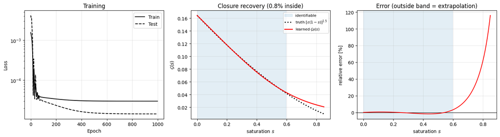

| 항목 | 값 |
| --- | --- |
| 그래디언트 검증 (최소 \|ratio−1\|) | **6.28 × 10⁻⁸** @ h=1e-6 |
| 복원 오차 (식별 구간 내부) | **0.8%** |
| 복원 오차 (구간 외부) | 34.5% |
| 학습 | 999 epoch까지 계속 개선 |

$\eta$ 다양화가 큰 $s$ 신호까지 보강 — A1의 16.4% → 0.8%로 크게 개선.

## 남기는 문제

아직 자기참조 비선형(Newton)에 도달하지 않음. 경계항은 검증됐지만 tangent 자체는 여전히 상수 계수 구조.

# A3. 비선형 low-s (Newton + K_corr)

## 점검 목표

$s = s(C)$로 자기참조 비선형이 될 때, Newton과 tangent 보정항 $K_{\text{corr}}$을 포함한 adjoint가 정확한가.

$$s(C) = S_{\max}\cdot\text{smooth-clip}\!\left(\frac{C_{\text{HI}}-C}{C_{\text{HI}}-C_{\text{LO}}}\right)$$

## 핵심 — tangent에 K_corr 등장

$$K_T = \underbrace{K_{\text{std}}}_{D_{\text{eff}}\text{를 고정 계수로 미분}}
+ \underbrace{\int \frac{\partial D_{\text{eff}}}{\partial s}\frac{\partial s}{\partial C}\,\delta C\,(\nabla C\cdot\nabla v)\,dx}_{K_{\text{corr}}}$$

$K_{\text{corr}}$ — $D_{\text{eff}}$가 $C$를 통해 변하는 것을 tangent가 반영하는 항. 없으면 Newton이 2차 수렴하지 않는다.

## 스니펫 — K_corr 조립

UFL이 $\partial s/\partial C$를 자동 미분, 신경망 미분 $\partial D_{\text{eff}}/\partial s$만 공급:

```python
J_std  = derivative(F_res, C_sol, C_tr)             # Deff_fn을 고정 계수로 미분
ds_dC_dir = derivative(s_ufl(C_sol), C_sol, C_tr)    # UFL이 ∂s/∂C 자동 미분
J_corr = dDeff_fn*ds_dC_dir*inner(grad(C_sol), grad(v_te))*dx
J_tan  = J_std + J_corr
```

**비선형 adjoint 부호 — A1/A2와 반대**:

$$K_T^{\top}\psi = +\frac{2r}{\lVert o\rVert^2},
\qquad
\frac{\partial J}{\partial D_{\text{eff}}} = -\,w_{qp}(\nabla C\cdot\nabla\psi)$$

## 결과 — Newton 수렴 (η=0.25 대표)

| 반복 | \|F\| |
| --- | --- |
| 0 | 4.87 × 10⁻⁷ |
| 1 | 6.24 × 10⁻⁸ |
| 2 | 8.08 × 10⁻⁹ |
| 3 | 7.09 × 10⁻¹¹ |
| 4 | 1.02 × 10⁻¹⁵ |

## 결과 — 그래디언트 검증 및 복원

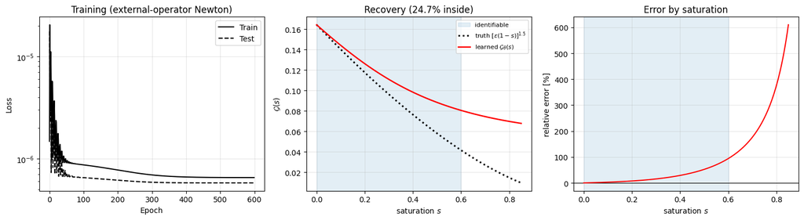

| 항목 | 값 |
| --- | --- |
| 그래디언트 검증 (최소 \|ratio−1\|) | **3.75 × 10⁻⁶** @ h=1e-5 |
| $\eta$ 범위 | 0.15 / 0.20 / 0.25 (제약 없이 수렴하는 범위) |
| $s$ 도달 범위 | [0, 0.088] |
| 복원 오차 — 전체 | 24.7% |
| 복원 오차 — $s\in[0,0.2)$ | **3.0%** |
| 복원 오차 — $s\in[0.2,0.4)$ | 16.1% |
| 복원 오차 — $s\in[0.4,0.6)$ | 55.0% |

## 남기는 문제

비선형 배선 자체는 **완전히 검증**됐다. 그런데 $\eta$를 이 범위로 제한해야만 Newton이 안정적으로 수렴 → $s$가 0.09까지만 도달.

→ 큰 $s$ 학습은 실질적으로 안 됨. **약한 비선형 조건의 정직한 결과**(버그 아님).

큰 $s$를 정직하게 다루려면 (인위적 매핑 조작 없이) **box 제약이 필요** → A4.

# A4. 비선형 high-s (box 제약)

## 점검 목표 · 설계

box 제약 $C \ge 0$ 하에서 활성집합(active-set) 축소 adjoint가 정확한가.

$$K_T^{\top}\big|_{\mathcal{II}}\,\psi_{\mathcal I} = \left(\frac{\partial J}{\partial C}\right)_{\mathcal I},
\qquad \psi_{\mathcal A} = 0$$

$\mathcal I$ = 비활성(자유) dof, $\mathcal A$ = 활성($C{=}0$ 고정) dof.

## 스니펫 — 활성집합 루프 + 축소 adjoint

```python
# 순전파: unconstrained trial → 음수 dof를 활성집합으로 고정 → 재수렴
neg = {dof : C[dof] < 0} - bc_rows
active |= neg                              # C=0으로 고정

# adjoint: 활성 dof를 Dirichlet처럼 취급
fixed = bc_rows | active
rr[list(fixed)] = 0.0                      # psi_A = 0
ksp.solveTranspose(rr, psi)
```

## 실행 결과 — 대조군 통과, 실험군 붕괴

| $\eta$ | 활성 dof | inner its | 그래디언트 검증 |
| --- | --- | --- | --- |
| 0.20 (대조군) | 0 | 4 | **3.83 × 10⁻⁸ PASS** |
| 0.35 | 3 | 5 | 3.69 × 10⁴ FAIL |
| 0.45 | **115** (전체 403의 29%) | **0** | 1.19 × 10⁴ FAIL |

`inner its=0` — Newton이 반복도 못 하고 dof 30%를 0으로 누른 채 종료. “s reached 0.599”는 물리적 충전이 아니라 **강제로 눌러 만든 인공물**.

## 실행 결과 — 학습 붕괴

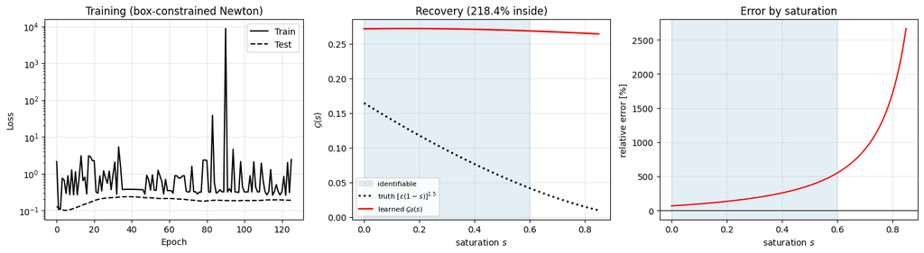

| 항목 | 값 |
| --- | --- |
| 복원 오차 — 전체 | **218.4%** |
| 복원 오차 — $s\in[0,0.2)$ | 94.7% |
| 복원 오차 — $s\in[0.2,0.4)$ | 185.0% |
| 복원 오차 — $s\in[0.4,0.6)$ | 375.6% |

학습 곡선이 요동치며 발산 방향 — 그래디언트 자체가 정의되지 않는 영역에서 학습을 시도한 결과.

## 남은 문제 ① — 활성집합이 θ에 불연속

$\eta=0.35$ 그래디언트 검증, 섭동 크기 $h$에 따른 활성 dof 개수:

| $h$ | 1e-2 | 1e-3 | 1e-4 | 1e-5 | 1e-6 | 1e-7 |
| --- | --- | --- | --- | --- | --- | --- |
| active(h) | 41 | 0 | 7 | 13 | 20 | 20 |

$\theta$를 아주 조금만 흔들어도 활성집합이 요동 → **목적함수가 그 지점에서 미분 불가능**.

대조군은 통과했으므로 **코드 버그가 아니라 문제의 수학적 성질**. (Bukshtynov 서베이의 경고 — PDE 시스템 상태 의존 역문제에서 단조성·최대원리 붕괴 — 의 구체적 발현)

## 남은 문제 ② — box와 continuation은 분리 불가능

A4를 “box만 추가”로 쪼갠 것 자체가 잘못된 분리였다.

**“$\eta$ 간격을 좁혀 안정 구간을 찾자”는 접근의 결함**:

- **(a) 존재 근거 없음** — 활성 dof가 0 → 3 → 115로 점프. 산소 고갈이 공간적으로 연속이라 활성집합 경계 자체가 $\theta$에 민감하게 반응. 작고 안정된 중간 지대가 있다는 보장이 없다.
- **(b) 설령 있어도 대표성 없음** — 활성 2~3개짜리 구간을 찾아도 그건 “box가 겨우 켜지는 경계”일 뿐, 실제 flooding의 활성 115개 상황을 대변하지 못한다.

## 남은 문제 ③ — 솔버 교체로는 안 풀린다

PETSc VI 솔버(`vinewtonrsls`, `vinewtonssls`)는 모두 **활성집합 계열** — 우리 수동 구현과 원리가 같다.

→ 순전파는 더 견고해질 수 있어도 **미분 가능성 문제는 그대로.**

필요한 건 솔버(순전파 평가기) 교체가 아니라 **접근 자체의 전환**:

- Interior-point — 활성집합 개념이 없어 매끄러움
- Smoothed complementarity
- Penalty — 잔차에 매끄러운 벌점항 추가, 사실상 A3 순수 Newton + 벌점

penalty 방식은 사실상 **본체의 continuation과 한 몸** → 인공 데이터로 미리 재현하는 가치가 작음.

## 결론 — A4는 “검증”이 아니라 “발견”

**밝힌 것**: box 제약만으로는 강한 비선형 영역에서 adjoint가 성립하지 않는다. 매끄러운 그래디언트에는 continuation 또는 smoothed complementarity가 필수다.

이건 실패가 아니라 **사다리 설계에 대한 교정** — box와 continuation의 분리 불가능성을 발견한 것. 대조군이 통과했으므로 여기까지의 배선(A1–A3 + 활성집합 축소 adjoint 자체)은 정상임이 확인됐다.

**다음 방향**:

- **B (mixed space)** — continuation과 독립적 → 지금 격리 검증 가능
- **box + continuation** — 본체에서 실제 continuation 인프라(§3.14)와 함께 다룸